# Viabilidad 09

una línea de envasado automatizada: umbrales de precio, volumen y coste variable; escenarios; inflación 3%

# Enunciado

Una empresa estudia invertir en una línea de envasado automatizada (datos adjuntos; mismas hipótesis contables que en el caso base: amortización lineal hasta el valor residual, circulante como fracción de las ventas aportado al principio de cada año y recuperado al final, valor residual cobrado por su valor contable). Antes de decidir, la dirección quiere saber *cuánto pueden equivocarse* las previsiones sin que el proyecto deje de ser viable.

1. Calcule los flujos de caja libre y el VAN del caso base.

2. Umbrales de rentabilidad: ¿qué precio mínimo, qué volumen mínimo del año 1 y qué coste variable máximo hacen el VAN igual a cero (manteniendo lo demás)? Exprese cada uno como variación porcentual respecto al caso base. ¿A qué variable es más sensible el proyecto?

3. Escenarios: pesimista (precio −10 %, unidades −10 %, costes fijos +10 %), base y optimista (precio +10 %, unidades +10 %, costes fijos −10 %). VAN y TIR de cada uno.

4. Los datos están en euros constantes. Si se espera una inflación del 3% anual que afecta por igual a precios y costes, ¿cómo deben construirse los flujos en euros corrientes y qué tasa nominal hay que usar para que el VAN no cambie? Compruébelo (relación de Fisher).

Tabla 1: Datos del caso

| parametro | valor |
| --- | --- |
| inversión inicial (k€) | 1110.00 |
| vida del proyecto (años) | 6.00 |
| precio (€ por miles de unidade) | 3.00 |
| miles de unidades vendidas el año 1 | 370.00 |
| crecimiento anual de las unidades | 0.08 |
| coste variable unitario (€) | 2.00 |
| costes fijos anuales (k€) | 120.00 |
| valor residual al final (k€) | 110.00 |
| circulante necesario (fracción de las ventas del año) | 0.05 |
| tipo impositivo | 0.25 |
| tasa de descuento | 0.10 |

# Resolución

## Apartado 1

1. Calcule los flujos de caja libre y el VAN del caso base.

Tabla 2: Flujos de caja libre del proyecto (k€)

| año | 0 | 1 | 2 | 3 | 4 | 5 | 6 |
| --- | --- | --- | --- | --- | --- | --- | --- |
| unidades | 0.0 | 370.0 | 399.6 | 431.6 | 466.1 | 503.4 | 543.7 |
| ventas | 0.0 | 1110.0 | 1198.8 | 1294.7 | 1398.3 | 1510.1 | 1631.0 |
| costes variables | 0.0 | 740.0 | 799.2 | 863.1 | 932.2 | 1006.8 | 1087.3 |
| costes fijos | 0.0 | 120.0 | 120.0 | 120.0 | 120.0 | 120.0 | 120.0 |
| EBITDA | 0.0 | 250.0 | 279.6 | 311.6 | 346.1 | 383.4 | 423.7 |
| amortización | 0.0 | 166.7 | 166.7 | 166.7 | 166.7 | 166.7 | 166.7 |
| BAI | 0.0 | 83.3 | 112.9 | 144.9 | 179.4 | 216.7 | 257.0 |
| impuesto | 0.0 | 20.8 | 28.2 | 36.2 | 44.9 | 54.2 | 64.2 |
| BDI | 0.0 | 62.5 | 84.7 | 108.7 | 134.6 | 162.5 | 192.7 |
| + amortización | 0.0 | 166.7 | 166.7 | 166.7 | 166.7 | 166.7 | 166.7 |
| − Δ circulante | -55.5 | -4.4 | -4.8 | -5.2 | -5.6 | -6.0 | 81.5 |
| − inversión | -1110.0 | -0.0 | -0.0 | -0.0 | -0.0 | -0.0 | -0.0 |
| + valor residual | 0.0 | 0.0 | 0.0 | 0.0 | 0.0 | 0.0 | 110.0 |
| FCL | -1165.5 | 224.7 | 246.6 | 270.2 | 295.6 | 323.2 | 551.0 |

Siglas: EBITDA, resultado antes de intereses, impuestos y amortizaciones; BAI, beneficio antes de impuestos; BDI, beneficio después de impuestos; FCL, flujo de caja libre (lo que el proyecto deja disponible cada año, en k€). Cálculo detallado del año 1 y de los años 0 y n:

- Ventas_1 = unidades × precio = 370.0 × 3 = 1110.0; costes variables = 370.0 × 2 = 740.0; EBITDA_1 = 1110.0 − 740.0 − 120.0 = 250.0.

- Amortización anual = (I0 − VR)/n = (1110 − 110)/6 = 166.7; BAI_1 = 250.0 − 166.7 = 83.3; impuesto_1 = 0.25 × 83.3 = 20.8; BDI_1 = 83.3 − 20.8 = 62.5.

- Circulante (se aporta al principio de cada año, es decir, al final del anterior): en t = 0 el del año 1, 0.05 × 1110.0 = 55.5; en cada momento t = 1…5, el aumento que necesitan las ventas del año siguiente, 0.05 × (ventas_t+1 − ventas_t) (en t = 1: 0.05 × (1198.8 − 1110.0) = 4.4); en t = 6 se recupera todo el circulante acumulado, 0.05 × 1631.0 = 81.5.

- FCL_0 = BDI + amortización − Δ circulante − inversión + valor residual = 0.0 + 0.0 − 55.5 − 1110.0 + 0.0 = **−1165.5**; FCL_1 = BDI + amortización − Δ circulante − inversión + valor residual = 62.5 + 166.7 − 4.4 + 0.0 + 0.0 = **224.7**; FCL_6 = BDI + amortización − Δ circulante − inversión + valor residual = 192.7 + 166.7 + 81.5 + 0.0 + 110.0 = **551.0**.

VAN = Σ flujo_t/(1 + k)^t = −1165.5 + 224.7/1.1¹ + 246.6/1.1² + 270.2/1.1³ + 295.6/1.1⁴ + 323.2/1.1⁵ + 551.0/1.1⁶ = −1165.5 + 204.3 + 203.8 + 203.0 + 201.9 + 200.7 + 311.0 = **159.1 k€**.

La TIR es la tasa que anula el VAN. Probando tasas: VAN(13%) = 35.1 k€ y VAN(14%) = −2.4 k€ tienen signo distinto, así que la TIR está entre 13% y 14%; interpolando linealmente, TIR ≈ 13% + 1 % × 35.1/(35.1 − (−2.4)) = 13.94%. Afinando (bisección, o =TIR(rango de flujos) en la hoja de cálculo): **TIR = 13.93%**. Comprobación: VAN(13.93%) = 0.0000 ≈ 0.

**Respuesta:** VAN del caso base = 159.1 k€ (TIR 13.93%): viable.

## Apartado 2

2. Umbrales de rentabilidad: ¿qué precio mínimo, qué volumen mínimo del año 1 y qué coste variable máximo hacen el VAN igual a cero (manteniendo lo demás)? Exprese cada uno como variación porcentual respecto al caso base. ¿A qué variable es más sensible el proyecto?

Cada umbral es el valor de la variable x que hace VAN(x) = 0 con las demás fijas. El VAN es casi lineal en cada variable, así que el umbral se aproxima bien con una regla de tres: VAN(x) ≈ VAN_base + (x − x_base) · ΔVAN/Δx, donde ΔVAN/Δx se mide cambiando la variable un 1 %; después se afina por bisección y se comprueba que el VAN en el umbral es 0. La sensibilidad se lee en la variación porcentual que anula el VAN: cuanto menor, más frágil es el proyecto frente a esa variable.

|  | caso base | ΔVAN por unidad de la variable | umbral ≈ base − VAN / pendiente | umbral exacto (VAN = 0) | VAN en el umbral | variación admisible |
| --- | --- | --- | --- | --- | --- | --- |
| precio | 3.000 | 1436.84 | 3 − 159.1/(1436.84) = 2.889 | 2.889 | 0.0000 | -3.7% |
| unidades año 1 | 370.000 | 3.83 | 370 − 159.1/(3.83) = 328.463 | 328.463 | 0.0000 | -11.2% |
| coste variable | 2.000 | -1446.48 | 2 − 159.1/(−1446.48) = 2.110 | 2.110 | 0.0000 | +5.5% |

**Respuesta:** precio: mínimo 2.889 (-3.7% respecto a 3); unidades año 1: mínimo 328.463 (-11.2% respecto a 370); coste variable: máximo 2.110 (+5.5% respecto a 2). El proyecto es más sensible a la variable **precio**: basta una variación del -3.7% para anular el VAN. El diagrama de araña muestra lo mismo: la recta más inclinada (en % de variación) es la de la variable más sensible.

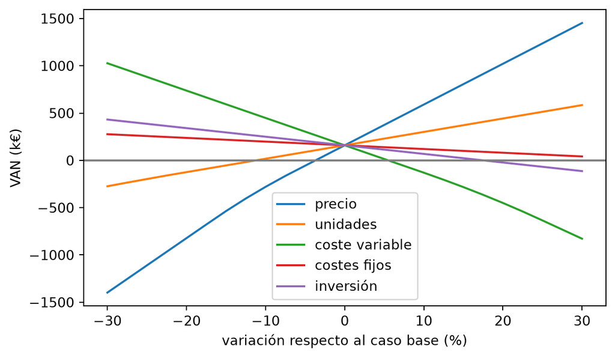

Figura 1: VAN frente a la variación de cada variable (diagrama de araña)

## Apartado 3

3. Escenarios: pesimista (precio −10 %, unidades −10 %, costes fijos +10 %), base y optimista (precio +10 %, unidades +10 %, costes fijos −10 %). VAN y TIR de cada uno.

Cada escenario repite el modelo completo con los tres datos cambiados a la vez; la tabla da sus flujos de caja libre y, debajo, el VAN término a término y la TIR.

| año | 0 | 1 | 2 | 3 | 4 | 5 | 6 |
| --- | --- | --- | --- | --- | --- | --- | --- |
| pesimista | -1155.0 | 97.5 | 115.9 | 135.7 | 157.1 | 175.6 | 375.6 |
| base | -1165.5 | 224.7 | 246.6 | 270.2 | 295.6 | 323.2 | 551.0 |
| optimista | -1177.2 | 352.1 | 383.4 | 417.3 | 453.8 | 493.2 | 752.4 |

|  | VAN (k€) | TIR |
| --- | --- | --- |
| pesimista | -440.2 | -2.04% |
| base | 159.1 | 13.93% |
| optimista | 814.2 | 28.50% |

- pesimista (precio 2.7, unidades 333, costes fijos 132): VAN = Σ flujo_t/(1 + k)^t = −1155.0 + 97.5/1.1¹ + 115.9/1.1² + 135.7/1.1³ + 157.1/1.1⁴ + 175.6/1.1⁵ + 375.6/1.1⁶ = −1155.0 + 88.6 + 95.8 + 101.9 + 107.3 + 109.0 + 212.0 = **−440.2 k€**; TIR = -2.04%.

- optimista (precio 3.3, unidades 407, costes fijos 108): VAN = Σ flujo_t/(1 + k)^t = −1177.2 + 352.1/1.1¹ + 383.4/1.1² + 417.3/1.1³ + 453.8/1.1⁴ + 493.2/1.1⁵ + 752.4/1.1⁶ = −1177.2 + 320.1 + 316.9 + 313.5 + 309.9 + 306.3 + 424.7 = **814.2 k€**; TIR = 28.50%.

**Respuesta:** VAN y TIR: pesimista -440.2 k€ y -2.04%; base 159.1 k€ y 13.93%; optimista 814.2 k€ y 28.50%. El escenario pesimista destruye la viabilidad (su TIR queda por debajo de la tasa del 10%). Los escenarios combinan desviaciones simultáneas, que es lo que ocurre en la práctica (un mal año afecta a precio y volumen a la vez); el análisis de una variable cada vez las subestima.

## Apartado 4

4. Los datos están en euros constantes. Si se espera una inflación del 3% anual que afecta por igual a precios y costes, ¿cómo deben construirse los flujos en euros corrientes y qué tasa nominal hay que usar para que el VAN no cambie? Compruébelo (relación de Fisher).

En euros corrientes, todo importe que sigue a los precios se multiplica en el año t por (1 + π)^t (ventas, costes variables y fijos y, con ellas, el circulante); la amortización y el valor residual, que dependen del precio de compra, no cambian. Esos flujos se descuentan a la tasa nominal, que incluye la inflación: relación de Fisher, (1 + k_nominal) = (1 + k_real)(1 + π).

| año | 0 | 1 | 2 | 3 | 4 | 5 | 6 |
| --- | --- | --- | --- | --- | --- | --- | --- |
| euros constantes | -1165.5 | 224.7 | 246.6 | 270.2 | 295.6 | 323.2 | 551.0 |
| euros corrientes | -1167.2 | 228.4 | 257.0 | 289.1 | 325.0 | 365.2 | 628.4 |

k_nominal = (1 + 0.1)(1 + 0.03) − 1 = 13.30%. Flujos corrientes descontados a la tasa nominal: VAN = Σ flujo_t/(1 + k)^t = −1167.2 + 228.4/1.133¹ + 257.0/1.133² + 289.1/1.133³ + 325.0/1.133⁴ + 365.2/1.133⁵ + 628.4/1.133⁶ = −1167.2 + 201.6 + 200.2 + 198.7 + 197.2 + 195.6 + 297.1 = **123.2 k€**. **Respuesta:** los flujos corrientes se construyen inflando cada año precios y costes con (1 + 0.03)^t y se descuentan al 13.30%. Con ello el VAN es 123.2 k€, frente a 159.1 con flujos constantes y tasa real: no coinciden exactamente porque no todo crece con la inflación: la amortización (y su ahorro fiscal) y el valor residual son importes nominales fijos, y el circulante crece con las ventas nominales; la inflación perjudica al proyecto vía impuestos y circulante (-35.9 k€). El error grave sería mezclar: flujos corrientes con tasa real daría 273.4 k€, un VAN inflado.